# ME323 - Introdução aos Modelos Probabilísticos

## Teste de Hipóteses: Introdução

## Exemplo: Astrólogos conseguem predizer nossa personalidade com um mapa astral?

## Exemplo: Astrólogos conseguem predizer nossa personalidade com um mapa astral?

- Se você fornece data, hora e local de nascimento, um astrólogo monta o seu Mapa Astral.
- *De acordo com a astrologia, a posição dos astros no momento em que nascemos influencia nossa maneira de ser.* - Wikipedia
- *As configurações de um Mapa Astral se repetem apenas a cada 26.000 anos, portanto ele é quase como uma impressão digital - não existe um igual ao outro.* - Wikipedia
- Há comprovação científica de que seu mapa astral reflete sua personalidade?

## Exemplo: Mapa Astral

Um teste foi feito da seguinte maneira: 116 pessoas selecionadas aleatoriamente forneceram data, hora e local de nascimento.

> Um astrólogo preparou um mapa astral para essas 116 pessoas, usando apenas os dados fornecidos acima.

> Cada voluntário também preencheu um questionário: "[California Personality Index](https://en.wikipedia.org/wiki/California_Psychological_Inventory)".

## Exemplo: Mapa Astral

Para **um outro astrólogo**, foram dados:

- data, hora, local, Mapa Astral de um dos voluntários, por exemplo, voluntário 3.
- questionário de personalidade preenchidos pelo voluntário 3.
- 2 questionários de personalidade, escolhidos ao acaso entre os 115 restantes, preenchidos por outros dois voluntários.
- Ao astrólogo, pediu-se então para identificar qual questionário havia sido preenchido pelo dono daquele Mapa Astral.

## Exemplo: Mapa Astral

- Seja \(p\) a probabilidade de que o astrólogo identifique o questionário correto.
- Se de fato a informação do Mapa Astral não caracteriza a personalidade de uma pessoa e na verdade o astrólogo está apenas escolhendo um dos 3 questionários ao acaso, a probabilidade de acerto é \(p=1/3\).
- Astrólogos confiam em seus estudos e dizem que a probabilidade de acerto é maior do que \(1/3\).
- Como testar se eles estão certos?
- Escolher ao acaso um astrólogo e fazer o teste com ele uma vez, é suficiente?

## Exemplo: Mapa Astral

- 28 astrólogos foram selecionados aleatoriamente a partir de uma lista de astrólogos familiarizados com o "California Personality Index".
- A lista foi preparada pelo ["National Council for Geocosmic Research"](https://geocosmic.org/).
- Vimos que podemos estudar fenômenos aleatórios definindo variáveis aleatórias e teoria da probabilidade.
- Um astrólogo pode associar corretamente o questionário ao mapa astral ou não.
- Para cada situação, há uma probabilidade associada. Portanto temos um evento aleatório.

## Exemplo: Mapa Astral

Como definir a variável aleatória?

- \(X_i\): astrólogo associa corretamente um questionário ao mapa astral \(i\), ou seja, \[X_i\sim \mbox{Bernoulli}(p)\]
- Podemos pensar em \(p\) como a proporção de acerto na população de astrólogos.
- Se astrólogos não têm a capacidade de predição, \(p = 1/3\).
- Astrólogos alegam que são capazes: \(p>1/3\).
- Como usar dados para testar estes dois cenários?

## Exemplo: Astrólogos conseguem predizer nossa personalidade com um mapa astral?

[figure not shown]

## Definindo hipóteses

- Objetivo em muitos estudos: checar se os dados apóiam certas afirmações que são feitas para uma população.
- Afirmações a serem testadas: **hipóteses**.
- Expressamos as hipóteses em termos dos parâmetros da população.
- Por exemplo: o parâmetro pode ser uma proporção populacional.

## Exemplo: Mapa Astral

**Hipótese:** *Usando o mapa astral de uma pessoa, a probabilidade \(p\) de um astrólogo predizer corretamente qual dos 3 questionários está associado àquele mapa astral é igual a \(1/3\). Ou seja, os astrólogos apenas selecionam ao acaso um dos questionários.*

> Nesse caso, para saber se os astrólogos têm a capacidade de predizer a personalidade usando o mapa astral, usaríamos as seguintes **hipóteses**:

\[ \begin{cases} H_0: p = 1/3 & \mbox{(hipótese nula)} \\ H_A: p > 1/3 & \mbox{(hipótese alternativa)} \end{cases} \]

> No experimento com os 28 astrólogos, observar uma proporção alta de acertos pode ser uma evidência contra a hipótese de que \(p=1/3\).

## Passos de um teste de hipótese

- **Passo 1: Suposições**

O teste é válido sob algumas suposições. A mais importante assume que os dados do experimento foram produzidos através de um processo de aleatorização.

- **Passo 2: Hipóteses**

O teste de hipótese tem sempre duas hipóteses sobre o parâmetro populacional de interesse. As hipóteses devem ser definidas **antes** de se realizar o experimento e coletar dados.

- **Hipótese Nula (\(H_0\)):** afirma que o parâmetro populacional assume um dado valor.
- **Hipótese Alternativa (\(H_A\)):** afirma que o parâmetro populacional assume outros valores, diferente do valor descrito na \(H_0\).

## Exemplo: Mapa Astral

No experimento dos astrólogos, \(H_0\): \(p=1/3\) representa a hipótese de que **não há efeito**, no sentido de que os astrólogos não têm uma capacidade maior de predizer a personalidade usando o mapa astral.

> A hipótese alternativa, \(H_A\): \(p>1/3\), representa a hipótese de que **há efeito**, ou seja, os astrólogos têm uma capacidade de predizer a personalidade usando o mapa astral.

> **Em teste de hipóteses, mantém-se a favor de \(H_0\) a menos que os dados tragam grande evidência contra.**

> A hipótese nula é conservadora: "o réu é inocente até que se prove o contrário".

## Passos de um teste de hipótese

- **Passo 3: Estatística do teste**

Vimos que podemos usar uma estatística para estimar um parâmetro populacional. A **estatística do teste** descreve quão longe do parâmetro populacional usado na \(H_0\) a estimativa está.

> Por exemplo, se \(H_0:\) \(p=1/3\), e se \(\widehat p=40/116=0.345\), queremos uma estatística que quantifique quão longe está \(\widehat p=0.345\) de \(p=1/3\).
- **Passo 4: valor-de-p**

Para interpretar uma estatística do teste, vamos usar uma probabilidade para resumir a evidência contra \(H_0\). Esta probabilidade é chamada de **valor-de-p**.

## Passos de um teste de hipótese

- **Passo 5: Conclusão**

Baseado no valor-de-p, decidir se rejeita ou não a hipótese nula. Note que a conclusão é sempre em termos da hipótese nula: rejeitar ou não \(H_0\).

Mas quão pequeno deve ser o valor-de-p para ser considerado forte evidência contra \(H_0\)?

Geralmente, fixamos o **nível de significância** do teste (\(\alpha\)), e usamos a seguinte regra. É comum usarmos \(\alpha=0.05\).

- Se valor-de-p \(\leq \alpha\): rejeitamos \(H_0\), ou seja, os dados trazem forte evidência contra a hipóstese nula
- Se valor-de-p > \(\alpha\): não rejeitamos \(H_0\), ou seja, não temos evidência nos dados contra a hipótese nula

## Passos de um teste de hipótese

> Assumimos primeiro que \(H_0\) é verdadeira.

> Consideramos então todos os valores possíveis para a estatística do teste, de acordo com sua distribuição amostral.

> Calculamos a estatística do teste observada para o experimento realizado e verificamos onde, na distribuição amostral, ela se posiciona.

> Calculamos a probabilidade de um valor igual ou mais extremo ao da estatística do teste observada (valor-de-p). Mais extremo: mais evidência contra \(H_0\).

> Se o valor-de-p obtido é bem pequeno, por exemplo, \(0.01\), isto quer dizer que se \(H_0\) é verdadeira, então seria incomum obter uma amostra com os resultados como o observado. Um valor-de-p muito baixo traz fortes evidências contra \(H_0\).

## Exemplo: Mapa Astral

Distribuição amostral da proporção amostral \(\widehat p\) sob \(H_0\).

[figure not shown]

**valor-de-p** (área em azul): probabilidade da proporção amostral assumir um valor igual ao observado, \(\widehat p_{obs}\), ou mais extremo, sob \(H_0\).

## Exemplo: Mapa Astral

**Passo 1: Suposições**

- A variável de interesse é binária.
- \(X_i\): astrólogo \(i\) associa corretamente um questionário ao mapa astral, ou seja,  
  \[X_i\sim \mbox{Bernoulli}(p).\]
- Os dados foram obtidos usando processo de aleatorização: uma amostra aleatória de voluntários e astrólogos foi feita.
- Temos uma a.a. de tamanho \(116\). Portanto, a distribuição amostral da estimativa para \(p\), \(\widehat p\), tem distribuição aproximadamente normal, pelo TCL.

## Exemplo: Mapa Astral

**Passo 2: Hipóteses**

- \(H_0\): \(p = p_0 = 1/3\).
- \(H_A\): \(p > p_0 = 1/3\).

Em outras palavras:

- \(H_0\): Astrólogos *chutam* qual o questionário está associado ao mapa astral.
- \(H_A\): Astrólogos predizem melhor do que um *chute* qual o questionário está associado ao mapa astral.

## Exemplo: Mapa Astral

**Passo 3: Estatística do teste**

- Estatística do teste mede quão longe está a proporção amostral, \(\widehat p\), da proporção populacional, \(p\), assumindo que \(H_0\) seja verdadeira?
- Sabemos que: \[\widehat p\sim\mbox{N}\left(p,\frac{p(1-p)}{n}\right)\]
- Se \(H_0\) é verdadeira (\(p=p_0\)), então: \[\widehat p\sim\mbox{N}\left(p_0,\frac{p_0(1-p_0)}{n}\right)\]

## Exemplo: Mapa Astral

**Passo 3: Estatística do teste**

- A estatística do teste é: \[Z=\frac{\widehat p-p_0}{EP_0(\widehat p)}\] onde \(EP_0(\widehat p)\) é o erro padrão de \(\widehat p\) sob \(H_0\). Portanto,

> \[Z=\frac{\widehat p-p_0}{\sqrt{\frac{p_0(1-p_0)}{n}}} \overset{H_0}{\sim}\mbox{N}(0,1)\]
- A estatística do teste mede quão distante está \(\widehat p\) de \(p_0\) em unidades de "erro-padrão".

## Exemplo: Mapa Astral

**Passo 3: Estatística do teste**

- No experimento dos astrólogos, dentre 116 mapas, 40 foram corretamente associados ao questionário de personalidade. \[\widehat p = 40/116 = 0.345\]
- A estatística do teste observada é: \[z_{obs}=\frac{\widehat p-p_0}{\sqrt{\frac{p_0(1-p_0)}{n}}}= \frac{0.345-1/3}{\sqrt{\frac{1/3(1-1/3)}{116}}}=0.27\]
- A proporção amostral está a 0.27 erro-padrão de distância da proporção populacional, segundo \(H_0\).

## Exemplo: Mapa Astral

**Passo 4: Valor-de-p**

- Tendo observado \(z_{obs}=0.27\), isso traz evidência contra \(H_0\) a favor de \(H_A\)?
- Quão improvável é \(z_{obs}=0.27\) se a proporção de acertos dos astrólogos é de fato \(p=p_0=1/3\)?
- Valor-de-p: probabilidade de que uma estatística do teste assuma um valor igual ou mais extremo do que o observado, assumindo \(H_0\) verdadeira.
- Mais extremo: neste caso, é um maior valor de \(z_{obs}\), pois equivale a um maior \(\widehat p\), maior proporção amostral de acertos (astrólogos alegam que \(p>1/3\)).
- Valor-de-p: \(P(Z>z_{obs})=P(Z>0.27)=0.3936\), onde \(Z \sim \mbox{N}(0,1)\).

## Exemplo: Mapa Astral

Distribuição amostral da estatística do teste \(Z\) sob \(H_0\).

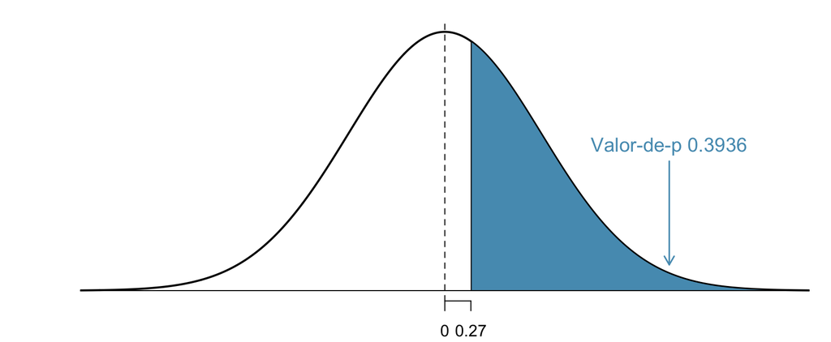

**valor-de-p** (área em azul): representa a probabilidade de valores mais extremos que \(z_{obs}\) ocorrerem.

## Exemplo: Mapa Astral

**Passo 5: Conclusão**

- O valor-de-p obtido no experimento foi 0.3936.
- O valor não é tão pequeno. Portanto, não temos evidências contra \(H_0\).
- Não podemos concluir que astrólogos têm poderes preditivos especiais usando mapa-astral.

[figure not shown]

Detalhes da pesquisa podem ser encontrados no artigo da revista Nature:  
[A double-blind test of Astrology](http://www.nature.com/nature/journal/v318/n6045/abs/318419a0.html).

## Resumo: Teste de Hipótese para uma proporção

## Resumo: Teste de Hipótese para uma proporção

Suponho que temos uma população e uma hipótese sobre a proporção \(p\) de indíviduos com certa característica.

**Hipóteses:**  
\[ \begin{aligned} H_0: p = p_0 \quad \mbox{vs} \quad H_A: & p \neq p_0 \mbox{ (bilateral)} \\ & p < p_0 \mbox{ (unilateral à esquerda)} \\ & p > p_0 \mbox{ (unilateral à direita)} \end{aligned} \]

**Estatística do teste:** Baseada na distribuição amostral de \(\widehat p\) \[Z=\frac{\widehat p-p_0}{\sqrt{\frac{p_0(1-p_0)}{n}}} \overset{H_0}{\sim} N(0,1)\]

**Condição:** \(np_0 ≥ 10\) e \(n(1−p_0) ≥ 10\) para aproximação normal

## Resumo: Teste de Hipótese para uma proporção

**valor-de-p**

- \(H_A: p \neq p_0\) (bilateral): valor-de-p=\(P(|Z| ≥|z_{obs}|)\)
- \(H_A: p < p_0\) (unilateral à esquerda): valor-de-p=\(P(Z \leq z_{obs})\)
- \(H_A: p > p_0\) (unilateral à direita): valor-de-p=\(P(Z \geq z_{obs})\)

**Conclusão**

Para um nível de significância \(\alpha\):

- Se valor-de-p \(\leq \alpha\): rejeitamos \(H_0\)
- Se valor-de-p > \(\alpha\): não rejeitamos \(H_0\)

## Exemplo: Efeitos Colaterais

Uma indústria farmacêutica diz que menos de 20% dos pacientes que estão usando um certo medicamento terão efeitos colaterais.

Realizou-se então um ensaio clínico com 400 pacientes e verificou-se que 68 pacientes apresentaram efeitos colaterais

**Hipóteses:** \(H_0: p = 0.20 \quad \mbox{vs} \quad H_A: p < 0.20\)

**Estatística do teste:** Da amostra temos que \(\widehat p = 68/400 = 0.17\) \[z_{obs} = \frac{\widehat p - p_0}{\sqrt{\frac{p_0(1-p_0)}{n}}} = \frac{0.17 - 0.20}{\sqrt{\frac{0.20(1-0.20)}{400}}} = -1.5\]

## Exemplo: Efeitos Colaterais

\[\mbox{valor-de-p} =P(Z \leq- 1.5) = 0.067\]

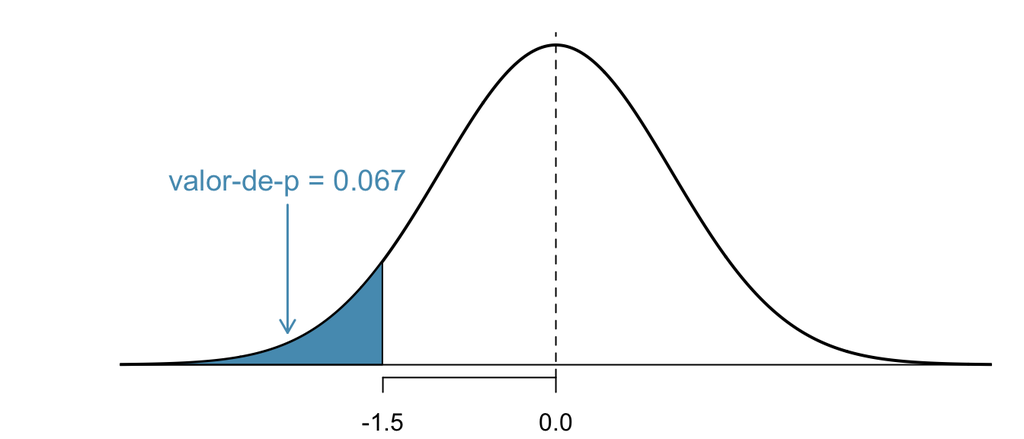

**Conclusão**: Para \(\alpha=0.05\), como o valor-de-p é maior que 0.05, não temos evidências nos dados para rejeitar a hipótese de que \(p=0.20\).

Na verdade, a evidência está na direção que a indústria farmacêutica queria, mas não é o suficiente para rejeitar \(H_0\).

## Exemplo: Efeitos Colaterais

E se estivéssemos testando: \(H_0: p = 0.20 \quad \mbox{vs} \quad H_A: p \neq 0.20\)

\(\begin{aligned} \mbox{valor-de-p} &=P(|Z| \geq 1.5) = P(Z \leq -1.5) + P(Z \geq 1.5) \\ &= 2P(Z \leq -1.5) = 2 \times 0.067=0.134 \end{aligned}\)

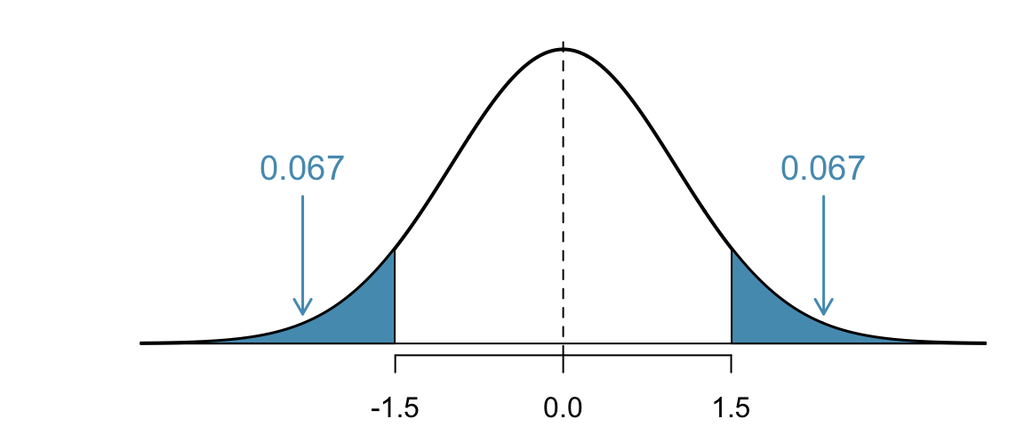

**Conclusão**: Para \(\alpha=0.05\), como o valor-de-p é maior que 0.05, não temos evidências nos dados para rejeitar a hipótese de que \(p=0.20\).

## Coca vs Coca Zero: Você consegue distinguir?

[figure not shown]

Algumas pessoas afirmam que conseguem distinguir o sabor da coca-cola normal da coca zero.

> Faremos então um teste para comprovar se a afirmação é verdadeira.

> Experimento:
- Sorteia-se, sem a pessoa saber, coca ou coca zero, usando um dado (se sair par, recebe uma coca-cola normal, se sair ímpar, uma coca zero.
- A bebida sorteada é então dada à pessoa, que deve experimentar e dizer que tipo de Coca-Cola está tomando.
- Repetimos isso 20 vezes e anotamos o total de acertos.

## Experimento da Coca vs Coca Zero

**Suposições:**

- Cada tentativa, \(X_i\), é uma Bernoulli\((p)\), em que \(p\) é a probabilidade de acerto.
- Estamos interessados no total de acertos em 20 tentativas: \(T=\sum_{i=1}^{20}X_i\sim\mbox{Bin}(20, p)\)
- Podemos usar a aproximação pela Normal caso as condições sejam satisfeitas.

> **Hipóteses:**
- \(H_0: p=1/2\) (a pessoa não consegue diferenciar as duas bebidas)
- \(H_A: p>1/2\).

## Experimento da Coca vs Coca Zero

[figure not shown]

> **Estatística do teste:** \(T=\sum_{i=1}^{20}X_i\sim\mbox{Bin}(20, p)\).

> **Valor-de-p:** evidência contra \(H_0\). Calculamos a probabilidade, sob \(H_0\), de ocorrer um valor igual ou mais extremo ao valor observado no experimento.

**Resultado do experimento:**

> Seja \(t_{obs}=19\) o número de acertos.

> Valor-de-p: \(P(T\geq 19)=0\), onde \(T\overset{H_0}{\sim}\mbox{Bin}(20, 1/2)\).

> **Conclusão:** Decidimos rejeitar \(H_0\).

## Experimento da Coca vs Coca Zero

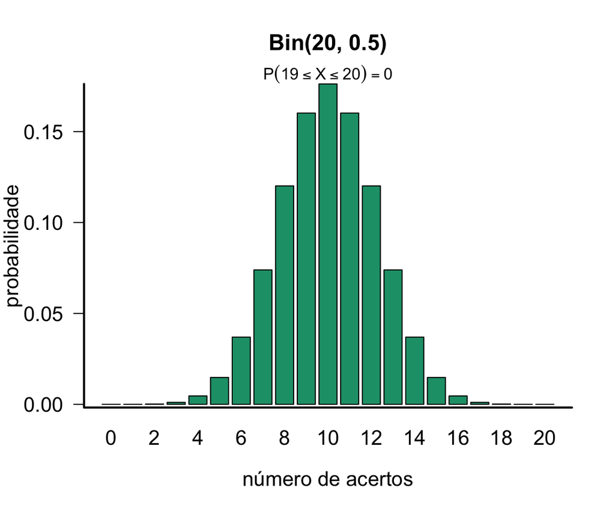

## Experimento da Coca vs Coca Zero

Seja \(T\) é o número de acertos. Utilizando a aproximação pela Normal, temos que \(T \sim Bin(20, p)\).

> A proporção amostral de acertos \(\widehat p = \frac{T}{20}= 19/20=0.95\).

> Vamos testar o seguinte: \(H_0: p = 0.50 \quad \mbox{vs} \quad H_A: p > 0.50\).

> **Estatística do teste:**

\[z_{obs} = \frac{\widehat p - p_0}{\sqrt{\frac{p_0(1-p_0)}{n}}} = \frac{0.95 - 0.5}{\sqrt{\frac{(0.50)(0.50)}{20}}} = 4.02\]

**valor-de-p** = \(P(Z \geq 4.02) = 0\)

**Conclusão:** Fixando \(\alpha=0.05\), rejeitamos a hipótese de que probabilidade de acertos é 50%.

## Experimento da Coca vs Coca Zero

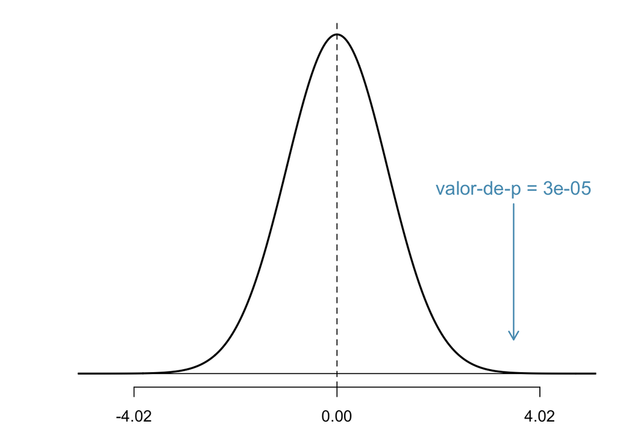

## Leituras

- Devore: capítulo 8.
- [Ross](http://www.sciencedirect.com/science/article/pii/B9780123743886000090): capítulo 9.
- [OpenIntro](https://www.openintro.org/stat/textbook.php): seções 4.3 e 6.1.
- Magalhães: capítulo 8.

Slides produzidos pelos professores:

- Samara Kiihl
- Tatiana Benaglia
- Benilton Carvalho